# Lineal Regression - Semana 2

angel

3/14/2020

## Semana 2

### Multiple Lineal Regression

El modelo lineal más simple se define como:

$$Y = \beta_{0}+\beta_{1}X_{1}+\beta_{2}X_{2}+...+\beta_{n}X_{n}+\epsilon$$

En este modelo $\beta_{j}$ se interpretan como el efecto promedio que tiene en $Y$ cuando $X_{j}$ aumenta en una unidad (cuando el resto de variables se encuentran fijas).

Veamos un caso con un dataset de marketing. La base de datos $\texttt{Advertising}$ (la cual pueden encontrar en el repositorio en GitHub: https://github.com/AFEScalante/StatisticalLearning.Curso ). Demos un vistazo a los datos y después empecemos a conjeturar algunas hipótesis.

```r
# Cargando paquetes del tidyverse
suppressPackageStartupMessages(library(tidyverse))
library(corrplot)
library(scatterplot3d)

# Leemos los datos
adv <- read_csv('./Advertising.csv')
# Primer vistazo a los datos
glimpse(adv)
```

```
## Observations: 200
## Variables: 5
## $ X1        <dbl> 1, 2, 3, 4, 5, 6, 7, 8, 9, 10, 11, 12, 13, 14, 15, 16, 17, …
## $ TV        <dbl> 230.1, 44.5, 17.2, 151.5, 180.8, 8.7, 57.5, 120.2, 8.6, 199…
## $ Radio     <dbl> 37.8, 39.3, 45.9, 41.3, 10.8, 48.9, 32.8, 19.6, 2.1, 2.6, 5…
## $ Newspaper <dbl> 69.2, 45.1, 69.3, 58.5, 58.4, 75.0, 23.5, 11.6, 1.0, 21.2, …
## $ Sales     <dbl> 22.1, 10.4, 9.3, 18.5, 12.9, 7.2, 11.8, 13.2, 4.8, 10.6, 8.…
```

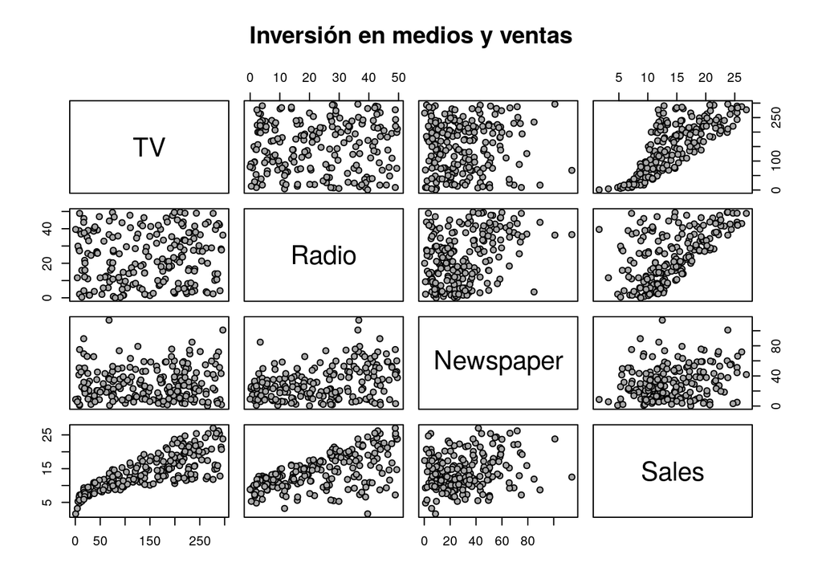

```r
# Primer vistazo gráfico
pairs(adv[, 2:ncol(adv)], main = 'Inversión en medios y ventas',
      pch = 21, bg = c("darkgray"))
```

Pareciera que hay una relación entre la inversión en TV, Radio y las Ventas. Confirmemos esto con una matriz de correlación.

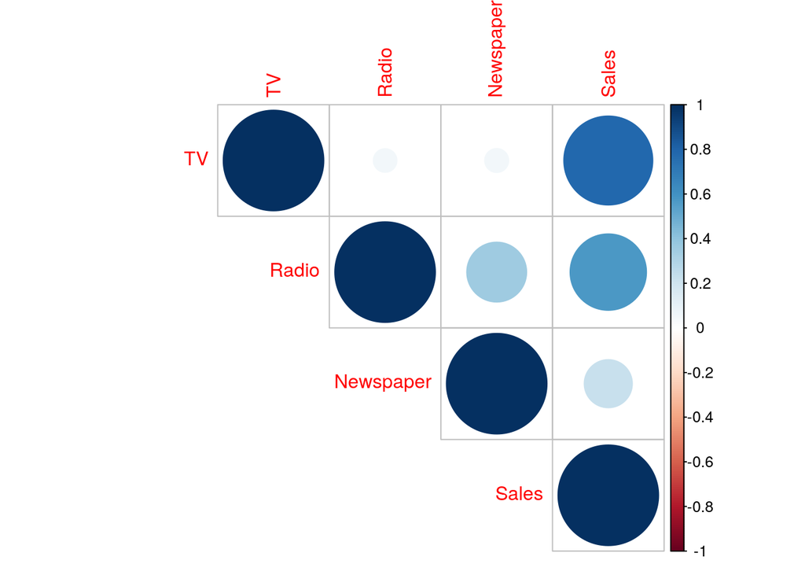

```r
# Matriz de correlación
cor_adv <- cor(adv[, -1])
corrplot(cor_adv, type = 'upper')
```

Con esto, podemos plantear los siguientes modelos uno a uno de la siguiente manera:

- $\texttt{sales} = \beta_{0}+\beta_{1}\texttt{TV}+\epsilon$
- $\texttt{sales} = \beta_{0}+\beta_{1}\texttt{Radio}+\epsilon$
- $\texttt{sales} = \beta_{0}+\beta_{1}\texttt{Newspaper}+\epsilon$

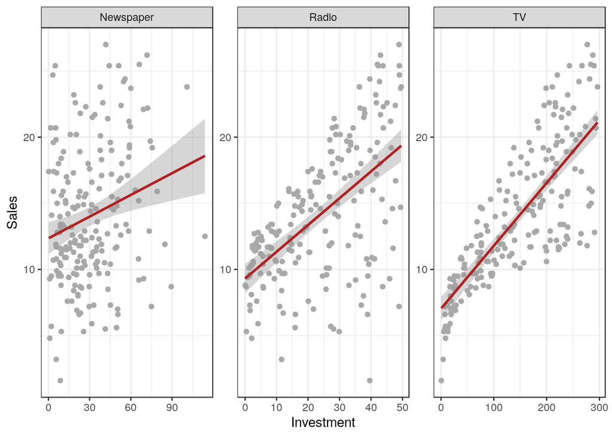

```r
# Apilando los datos para mejor visualización
adv_stacked <- adv %>% gather('Media', 'Value', 2:4)

# Regresión uno a uno
ggplot(adv_stacked, aes(x = Value, y = Sales)) + geom_point(col = 'darkgray') + theme_bw() +
  geom_smooth(method = "lm", se = TRUE, col = 'firebrick') + labs(x = 'Investment') +
  facet_wrap(~Media, scales = 'free')
```

```r
# Ventas contra inversión en periódicos
summary(lm(Sales ~ Newspaper, data = adv))
```

```
##
## Call:
## lm(formula = Sales ~ Newspaper, data = adv)
##
## Residuals:
##      Min       1Q   Median       3Q      Max
## -11.2272  -3.3873  -0.8392   3.5059  12.7751
##
## Coefficients:
##             Estimate Std. Error t value Pr(>|t|)
## (Intercept) 12.35141    0.62142   19.88  < 2e-16 ***
## Newspaper    0.05469    0.01658    3.30  0.00115 **
## ---
## Signif. codes:  0 '***' 0.001 '**' 0.01 '*' 0.05 '.' 0.1 ' ' 1
##
## Residual standard error: 5.092 on 198 degrees of freedom
## Multiple R-squared:  0.05212,    Adjusted R-squared:  0.04733
## F-statistic: 10.89 on 1 and 198 DF,  p-value: 0.001148
```

```r
# Ventas contra inversión en Radio
summary(lm(Sales ~ Radio, data = adv))
```

```
##
## Call:
## lm(formula = Sales ~ Radio, data = adv)
##
## Residuals:
##      Min       1Q   Median       3Q      Max
## -15.7305  -2.1324   0.7707   2.7775   8.1810
##
## Coefficients:
##             Estimate Std. Error t value Pr(>|t|)
## (Intercept)  9.31164    0.56290  16.542   <2e-16 ***
## Radio        0.20250    0.02041   9.921   <2e-16 ***
## ---
## Signif. codes:  0 '***' 0.001 '**' 0.01 '*' 0.05 '.' 0.1 ' ' 1
##
## Residual standard error: 4.275 on 198 degrees of freedom
## Multiple R-squared:  0.332,  Adjusted R-squared:  0.3287
## F-statistic: 98.42 on 1 and 198 DF,  p-value: < 2.2e-16
```

```r
# Ventas contra inversión en TV
summary(lm(Sales ~ TV, data = adv))
```

```
##
## Call:
## lm(formula = Sales ~ TV, data = adv)
##
## Residuals:
##     Min      1Q  Median      3Q     Max
## -8.3860 -1.9545 -0.1913  2.0671  7.2124
##
## Coefficients:
##             Estimate Std. Error t value Pr(>|t|)
## (Intercept) 7.032594   0.457843   15.36   <2e-16 ***
## TV          0.047537   0.002691   17.67   <2e-16 ***
## ---
## Signif. codes:  0 '***' 0.001 '**' 0.01 '*' 0.05 '.' 0.1 ' ' 1
##
## Residual standard error: 3.259 on 198 degrees of freedom
## Multiple R-squared:  0.6119, Adjusted R-squared:  0.6099
## F-statistic: 312.1 on 1 and 198 DF,  p-value: < 2.2e-16
```

Por último, verémos la diferencia con el modelo completo, un modelo en el que sean consideradas todas la variables:

$$\texttt{sales} = \beta_{0}+\beta_{1}\texttt{Newspaper}+\beta_{2}\texttt{Radio}+\beta_{3}\texttt{TV}+\epsilon$$

```r
# Ventas contra inversiones
summary(lm(Sales ~ .-X1, data = adv))
```

```
##
## Call:
## lm(formula = Sales ~ . - X1, data = adv)
##
## Residuals:
##     Min      1Q  Median      3Q     Max
## -8.8277 -0.8908  0.2418  1.1893  2.8292
##
## Coefficients:
##              Estimate Std. Error t value Pr(>|t|)
## (Intercept)  2.938889   0.311908   9.422   <2e-16 ***
## TV           0.045765   0.001395  32.809   <2e-16 ***
## Radio        0.188530   0.008611  21.893   <2e-16 ***
## Newspaper   -0.001037   0.005871  -0.177     0.86
## ---
## Signif. codes:  0 '***' 0.001 '**' 0.01 '*' 0.05 '.' 0.1 ' ' 1
##
## Residual standard error: 1.686 on 196 degrees of freedom
## Multiple R-squared:  0.8972, Adjusted R-squared:  0.8956
## F-statistic: 570.3 on 3 and 196 DF,  p-value: < 2.2e-16
```

Quitemos la variable $\texttt{Newspaper}$, ya que en el modelo completo vemos que el p-valor indica que no es estadísticamente significativo, veamos el modelo con $\texttt{TV}$ y $\texttt{Radio}$ y su representación gráfica en $R^3$.

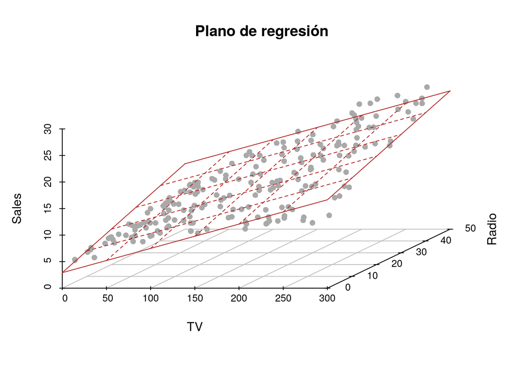

```r
# Ventas contra TV y Radio
mod <- lm(Sales ~ TV + Radio, data = adv)

# Plano en R3
plot3d <- scatterplot3d(adv$TV, adv$Radio, adv$Sales,
                        color = "darkgray", pch = 16, box = FALSE,
                        main ="Plano de regresión",
                        xlab = 'TV', ylab = 'Radio', zlab = 'Sales')
plot3d$plane3d(mod, lty.box = "solid", col = "firebrick")
```

### Interacciones entre variables